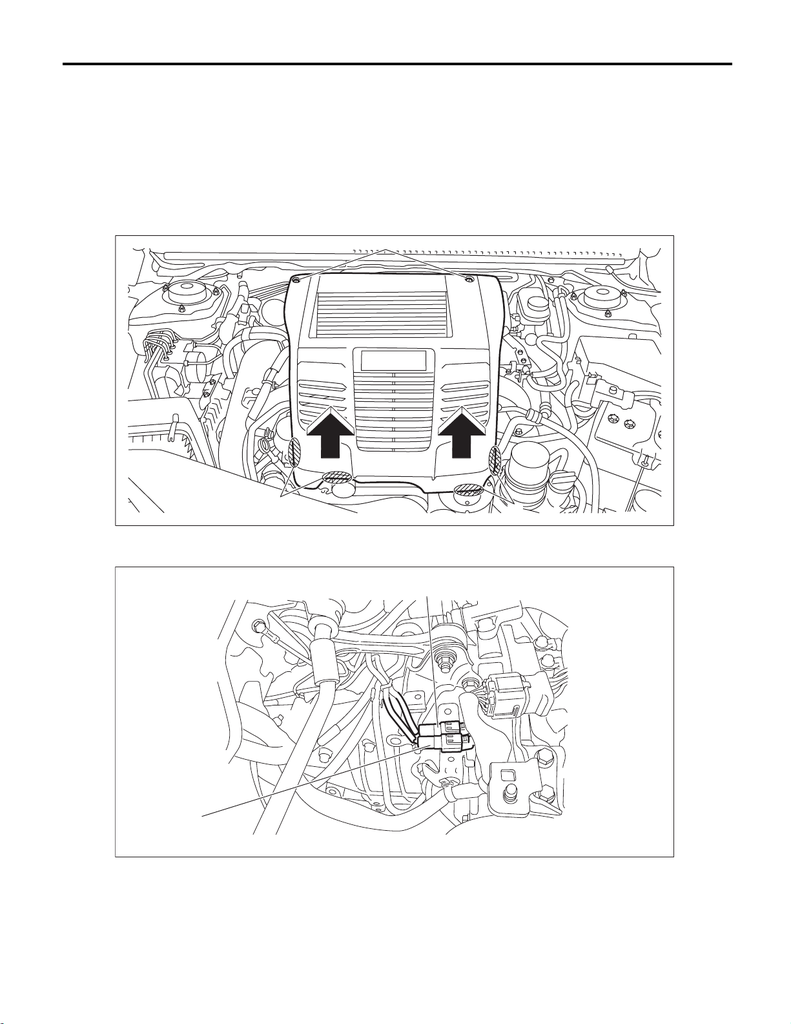

Switches and Harness

MANUAL TRANSMISSION AND DIFFERENTIAL

7. Switches and Harness

A: REMOVAL

1. BACK-UP LIGHT AND NEUTRAL POSITION SWITCH

1) Disconnect the ground cable from battery. <Ref. to NT-5, BATTERY, NOTE, Note.>

2) Remove the collector cover.

(1) Remove the clips (A).

(2) Hold the shaded area (B) by hand and carefully pull the RH side (C) upward.

(3) Hold the shaded area (D) by hand and carefully pull the LH side (E) upward.

3) Remove the intercooler. <Ref. to IN(w/o STI)-38, REMOVAL, Intercooler.>

4) Disconnect the connector back-up light switch & neutral position switch.

5) Remove the harness connector from bracket.

6) Lift up the vehicle.

7) Remove the harness from each clip.

(A) Neutral position switch connector

(brown)

(B) Back-up light switch connector

(gray)

EX-03204

(A)

(B)

(C)

(E)

(D)

MT-03111

(A)

(B)

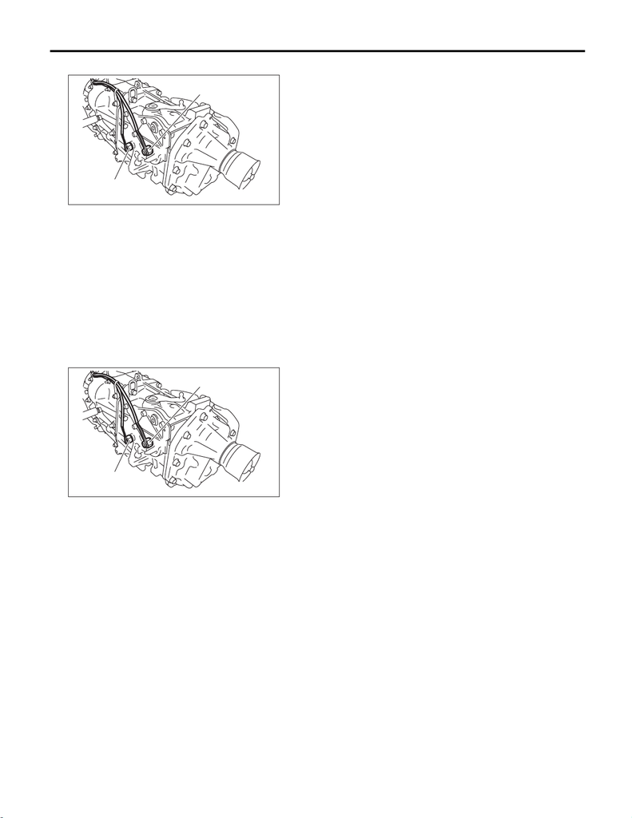

Switches and Harness

MANUAL TRANSMISSION AND DIFFERENTIAL

8) Remove the back-up light switch & neutral position switch with the harness.

B: INSTALLATION

1. BACK-UP LIGHT AND NEUTRAL POSITION SWITCH

1) Install the back-up light switch & neutral position switch with the harness.

NOTE:

Use a new gasket.

Tightening torque:

32.3 N·m (3.3 kgf-m, 23.8 ft-lb)

2) Secure the harness on each clip.

3) Lower the vehicle.

4) Install the harness connector to the bracket.

5) Connect the connectors of back-up light switch & neutral position switch.

6) Install the intercooler. <Ref. to IN(w/o STI)-41, INSTALLATION, Intercooler.>

7) Install the collector cover.

8) Connect the battery ground terminal. <Ref. to NT-5, BATTERY, NOTE, Note.>

MT-02447

(B)

(A)

(A) Neutral position switch

(B) Back-up light switch

MT-02447

(B)

(A)

(A) Neutral position switch

(B) Back-up light switch

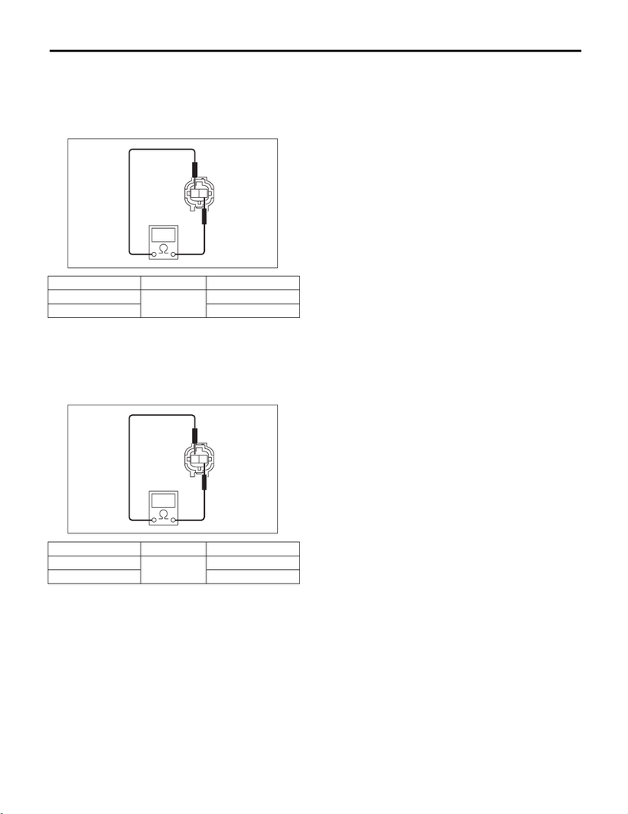

Switches and Harness

MANUAL TRANSMISSION AND DIFFERENTIAL

C: INSPECTION

1. BACK-UP LIGHT SWITCH

1) Turn the ignition switch to OFF.

2) Disconnect the back light switch connector.

3) Measure the resistance between the back-up light switch terminals.

4) Replace faulty parts.

2. NEUTRAL POSITION SWITCH

1) Turn the ignition switch to OFF.

2) Disconnect the connector of neutral position switch.

3) Measure the resistance between neutral position switch terminals.

4) Replace faulty parts.

2 1

MT-02787

Gear shift position Terminal No. Specified resistance

Reverse position

1 and 2

Less than 1 Ω

Other positions 1 MΩ or more

2 1

MT-02787

Gear shift position Terminal No. Specified resistance

Neutral position

1 and 2

Less than 1 Ω

Other positions 1 MΩ or more